# Regresion

Ignacio Vellido

11/17/2020

Cargamos los datos:

```r
names <- c("Displacement", "Horse_power", "Weight", "Acceleration", "Model_year", "Mpg")

auto <- read_csv("Data/autoMPG6/autoMPG6.dat", comment = "@", col_names = names)
```

Como se comentó en el apartado de EDA:

“Se nos pide elegir 5 regresores para la regresión y contamos exactamente con ese número, por lo que no podemos descartar ninguna variable. Aún así, hemos visto que tenemos algunas variables más interesentas que otras. Varibles correladas con la salida nos aumentan las posibilidades de obtener un buen regresor, pero debemos evitar usar variables correladas entre sí para evitar la multicolinealidad. Sería conveniente evitarla para aumentar la interpretabilidad del modelo, pero la potencia en sí de este no cambia.”

Graficamos la relación de cada variable respecto a la salida

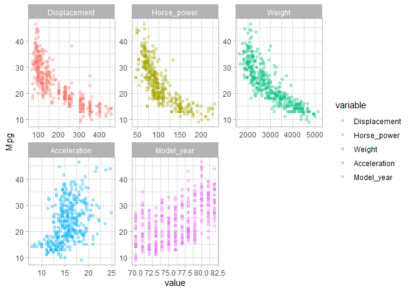

```r
ggplot(melt(auto, "Mpg"), aes(x=value, y=Mpg, color=variable)) +
  geom_point(alpha=0.3) +
  facet_wrap(.~variable, scale="free") +
  theme_light()
```

Como dijimos, se aprecia alta correlación entre Displacement, Horse_power, Weight respecto de la salida, probablemente de forma logarítmica.

Las matrices nos correlación nos confirman esta idea (con coeficientes de Pearson y Kendall)

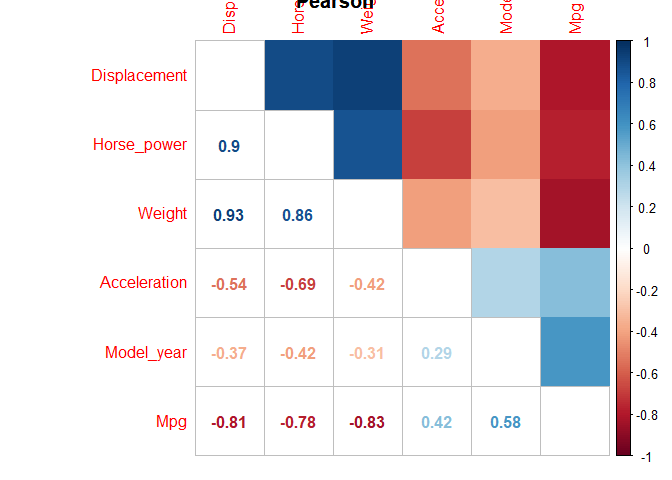

```r
corrplot.mixed(cor(auto), tl.pos="lt", upper="color", title="Pearson")
```

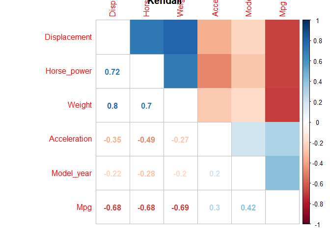

```r
corrplot.mixed(cor(auto, method="kendall"), tl.pos="lt", upper="color", title="Kendall")
```

Por tando, si las ordenáramos por cuáles parecen ser más prometedoras, tendríamos: Weight > Displacement > Horse_power > Model_year > Acceleration

También tenemos que tener en cuenta que las tres primeras variables están correladas entre sí.

## Ajustes de regresión lineal univariables

Vamos a analizar un ajuste con cada una de las características:

```r
lm(Mpg ~ Weight, data=auto) %>% summary()
print("-------------------------------------------")
lm(Mpg ~ Displacement, data=auto) %>% summary()
print("-------------------------------------------")
lm(Mpg ~ Horse_power, data=auto) %>% summary()
print("-------------------------------------------")
lm(Mpg ~ Model_year, data=auto) %>% summary()
print("-------------------------------------------")
lm(Mpg ~ Acceleration, data=auto) %>% summary()
```

```
Call:
lm(formula = Mpg ~ Weight, data = auto)

Residuals:
     Min       1Q   Median       3Q      Max
-11.9736  -2.7556  -0.3358   2.1379  16.5194

Coefficients:
             Estimate Std. Error t value Pr(>|t|)
(Intercept) 46.216524   0.798673   57.87   <2e-16 ***
Weight      -0.007647   0.000258  -29.64   <2e-16 ***
---
Signif. codes:  0 '***' 0.001 '**' 0.01 '*' 0.05 '.' 0.1 ' ' 1

Residual standard error: 4.333 on 390 degrees of freedom
Multiple R-squared:  0.6926,    Adjusted R-squared:  0.6918
F-statistic: 878.8 on 1 and 390 DF,  p-value: < 2.2e-16

[1] "-------------------------------------------"

Call:
lm(formula = Mpg ~ Displacement, data = auto)

Residuals:
     Min       1Q   Median       3Q      Max
-12.9170  -3.0243  -0.5021   2.3512  18.6128

Coefficients:
             Estimate Std. Error t value Pr(>|t|)
(Intercept)  35.12064    0.49443   71.03   <2e-16 ***
Displacement -0.06005    0.00224  -26.81   <2e-16 ***
---
Signif. codes:  0 '***' 0.001 '**' 0.01 '*' 0.05 '.' 0.1 ' ' 1

Residual standard error: 4.635 on 390 degrees of freedom
Multiple R-squared:  0.6482,    Adjusted R-squared:  0.6473
F-statistic: 718.7 on 1 and 390 DF,  p-value: < 2.2e-16

[1] "-------------------------------------------"

```

[output cut: 42 more lines]

```

Residuals:
    Min      1Q  Median      3Q     Max
-17.989  -5.616  -1.199   4.801  23.239

Coefficients:
             Estimate Std. Error t value Pr(>|t|)
(Intercept)    4.8332     2.0485   2.359   0.0188 *
Acceleration   1.1976     0.1298   9.228   <2e-16 ***
---
Signif. codes:  0 '***' 0.001 '**' 0.01 '*' 0.05 '.' 0.1 ' ' 1

Residual standard error: 7.08 on 390 degrees of freedom
Multiple R-squared:  0.1792,    Adjusted R-squared:  0.1771
F-statistic: 85.15 on 1 and 390 DF,  p-value: < 2.2e-16
```

Al ser univariable, no es necesario fijarse en el estadístico F por ahora. Para ver el potencial de la variable, debemos darle importancia al p-valor (comprobar de que sea lo suficientemente bajo), y posteriormente ver el R<sup>2</sup> para everiguar el porcentaje de la salida explicada.

En base a los resultados vemos que el test de correlación nos había ayudado correctamente: de forma individual todas las variables tienen dependencia lineal, y el orden de calidad coincide con el orden de fuerza en las correlaciones.

Guardamos el modelo aditivo hasta ahora

```r
fit <- lm(Mpg ~ Weight, data=auto)
```

Ya con el uso de la variable Weight vemos que podemos explicar un ~69% de la salida, un buen valor de partida. Graficamos el ajuste:

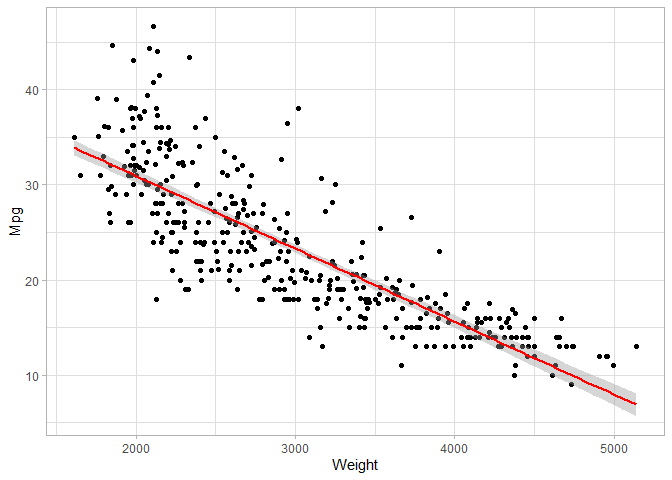

```r
ggplot(auto, aes(x=Weight, y=Mpg)) +
  geom_point() +
  geom_smooth(formula = y ~ x, method=lm, col="red") +
  theme_light()
```

Y vemos sus coeficientes:

```r
confint(fit)
```

```
                   2.5 %      97.5 %
(Intercept) 44.646282308 47.78676679
Weight      -0.008154515 -0.00714017
```

Aunque los valores del intervalo del coeficiente de Weight sea bajo, vemos que no incluye el cero (y con el p-valor obtenido anteriormente, lo podemos asegurar con bastante certeza). Probablemente la razón de estos coeficientes tan pequeños es que los datos no están estandarizados (se podría hacer perfectamente, se han dejado con sus rangos normales para interpretarlos mejor) y los valores de las unidades de medida son bastante diferentes (hablamos de rangos de [9.0,46.6] en Mpg frente a [1613,5140] en Weight)

## Ajustes de regresión lineal multivariable

Aplicamos un método descendente

```r
lm(Mpg ~ ., data=auto) %>% summary()
```

```
Call:
lm(formula = Mpg ~ ., data = auto)

Residuals:
    Min      1Q  Median      3Q     Max
-8.5211 -2.3920 -0.1036  2.0312 14.2874

Coefficients:
               Estimate Std. Error t value Pr(>|t|)
(Intercept)  -1.544e+01  4.677e+00  -3.300  0.00106 **
Displacement  2.782e-03  5.462e-03   0.509  0.61082
Horse_power   1.020e-03  1.376e-02   0.074  0.94095
Weight       -6.874e-03  6.653e-04 -10.333  < 2e-16 ***
Acceleration  9.032e-02  1.019e-01   0.886  0.37599
Model_year    7.541e-01  5.261e-02  14.334  < 2e-16 ***
---
Signif. codes:  0 '***' 0.001 '**' 0.01 '*' 0.05 '.' 0.1 ' ' 1

Residual standard error: 3.435 on 386 degrees of freedom
Multiple R-squared:  0.8088,    Adjusted R-squared:  0.8063
F-statistic: 326.5 on 5 and 386 DF,  p-value: < 2.2e-16
```

El p-valor del F estadístico nos dice que al menos hay una variable (realmente ya lo sabíamos de los ajustes univariables) con dependencia linea.

Vemos que hay 3 variables con mal p-valor, empezamos quitando la que lo tiene más alto, Horse_power

```r
lm(Mpg ~ . - Horse_power, data=auto) %>% summary()
```

```
Call:
lm(formula = Mpg ~ . - Horse_power, data = auto)

Residuals:
    Min      1Q  Median      3Q     Max
-8.5182 -2.3948 -0.1085  2.0405 14.2908

Coefficients:
               Estimate Std. Error t value Pr(>|t|)
(Intercept)  -1.527e+01  4.106e+00  -3.719 0.000229 ***
Displacement  2.874e-03  5.310e-03   0.541 0.588651
Weight       -6.852e-03  5.967e-04 -11.483  < 2e-16 ***
Acceleration  8.555e-02  7.885e-02   1.085 0.278595
Model_year    7.532e-01  5.118e-02  14.717  < 2e-16 ***
---
Signif. codes:  0 '***' 0.001 '**' 0.01 '*' 0.05 '.' 0.1 ' ' 1

Residual standard error: 3.431 on 387 degrees of freedom
Multiple R-squared:  0.8088,    Adjusted R-squared:  0.8068
F-statistic: 409.2 on 4 and 387 DF,  p-value: < 2.2e-16
```

El F estadístico está correcto, y seguimos teniendo variables con p-valor grande, quitamos Displacement

```r
lm(Mpg ~ . - Horse_power - Displacement, data=auto) %>% summary()
```

```
Call:
lm(formula = Mpg ~ . - Horse_power - Displacement, data = auto)

Residuals:
    Min      1Q  Median      3Q     Max
-8.6749 -2.3528 -0.1082  2.0168 14.3022

Coefficients:
               Estimate Std. Error t value Pr(>|t|)
(Intercept)  -14.936555   4.055512  -3.683 0.000263 ***
Weight        -0.006554   0.000230 -28.502  < 2e-16 ***
Acceleration   0.066359   0.070361   0.943 0.346204
Model_year     0.748446   0.050366  14.860  < 2e-16 ***
---
Signif. codes:  0 '***' 0.001 '**' 0.01 '*' 0.05 '.' 0.1 ' ' 1

Residual standard error: 3.428 on 388 degrees of freedom
Multiple R-squared:  0.8086,    Adjusted R-squared:  0.8071
F-statistic: 546.5 on 3 and 388 DF,  p-value: < 2.2e-16
```

idem. a lo anterior, quitamos Acceleration.

```r
lm(Mpg ~ . - Horse_power - Displacement - Acceleration, data=auto) %>% summary()
```

```
Call:
lm(formula = Mpg ~ . - Horse_power - Displacement - Acceleration,
    data = auto)

Residuals:
    Min      1Q  Median      3Q     Max
-8.8505 -2.3014 -0.1167  2.0367 14.3555

Coefficients:
              Estimate Std. Error t value Pr(>|t|)
(Intercept) -1.435e+01  4.007e+00  -3.581 0.000386 ***
Weight      -6.632e-03  2.146e-04 -30.911  < 2e-16 ***
Model_year   7.573e-01  4.947e-02  15.308  < 2e-16 ***
---
Signif. codes:  0 '***' 0.001 '**' 0.01 '*' 0.05 '.' 0.1 ' ' 1

Residual standard error: 3.427 on 389 degrees of freedom
Multiple R-squared:  0.8082,    Adjusted R-squared:  0.8072
F-statistic: 819.5 on 2 and 389 DF,  p-value: < 2.2e-16
```

El estadístico F sigue bien, y los p-valores de las variables son extremadamente bajos. Nos fijamos en el R<sup>2</sup> y vemos que ha subido considerablemente (un 10%) respecto al univariable, por lo que este sería nuestro modelo aditivo por ahora.

A partir de ahora hay que tener cuidado si el R<sup>2</sup> sigue aumentando, hay que evitar el overfitting en el modelo.

## Inserción de interacciones

Del modelo aditivo solo nos han quedado dos regresores, así que probamos a incluirlos como interacción.

```r
lm(Mpg ~ + Weight * Model_year, data=auto) %>% summary()
```

```
Call:
lm(formula = Mpg ~ +Weight * Model_year, data = auto)

Residuals:
    Min      1Q  Median      3Q     Max
-8.0397 -1.9956 -0.0983  1.6525 12.9896

Coefficients:
                    Estimate Std. Error t value Pr(>|t|)
(Intercept)       -1.105e+02  1.295e+01  -8.531 3.30e-16 ***
Weight             2.755e-02  4.413e-03   6.242 1.14e-09 ***
Model_year         2.040e+00  1.718e-01  11.876  < 2e-16 ***
Weight:Model_year -4.579e-04  5.907e-05  -7.752 8.02e-14 ***
---
Signif. codes:  0 '***' 0.001 '**' 0.01 '*' 0.05 '.' 0.1 ' ' 1

Residual standard error: 3.193 on 388 degrees of freedom
Multiple R-squared:  0.8339,    Adjusted R-squared:  0.8326
F-statistic: 649.3 on 3 and 388 DF,  p-value: < 2.2e-16
```

El F estadístico sigue bien y los p-valores son bajos, el nuevo R<sup>2</sup> ha mejorado un 3%, así que no es demasiado para considerar un overfitting. Probablemente más de un 90% sería preocupante, pero también tenemos que tener en cuenta que las variables están fuertemente correladas con la salida.

Podríamos probar a añadir alguna interacción más con alguna variable que no hubiera entrado en el modelo aditivo, pero no se espera que mejore:

```r
lm(Mpg ~ + Weight * Model_year + Acceleration * Displacement, data=auto) %>% summary()
```

```
Call:
lm(formula = Mpg ~ +Weight * Model_year + Acceleration * Displacement,
    data = auto)

Residuals:
    Min      1Q  Median      3Q     Max
-7.3130 -1.8670 -0.0426  1.6109 12.2499

Coefficients:
                            Estimate Std. Error t value Pr(>|t|)
(Intercept)               -1.131e+02  1.321e+01  -8.564 2.65e-16 ***
Weight                     2.456e-02  4.693e-03   5.234 2.73e-07 ***
Model_year                 1.907e+00  1.769e-01  10.778  < 2e-16 ***
Acceleration               7.273e-01  1.282e-01   5.671 2.79e-08 ***
Displacement               3.605e-02  8.673e-03   4.157 3.98e-05 ***
Weight:Model_year         -4.054e-04  6.281e-05  -6.454 3.29e-10 ***
Acceleration:Displacement -2.953e-03  6.219e-04  -4.748 2.91e-06 ***
---
Signif. codes:  0 '***' 0.001 '**' 0.01 '*' 0.05 '.' 0.1 ' ' 1

Residual standard error: 3.075 on 385 degrees of freedom
Multiple R-squared:  0.8472,    Adjusted R-squared:  0.8448
F-statistic: 355.7 on 6 and 385 DF,  p-value: < 2.2e-16
```

A pesar de nuestra suposición los p-valores son válidos y el R<sup>2</sup> aumenta un 1%. Es cuestionable si el aumento de la complejidad del modelo merece con este incremento de R<sup>2</sup>. Por simplificar vamos a quedarnos con el modelo aditivo anterior y probar con otra interacción.

Podemos probar combinando la variable Acceleration con una de que teníamos (Weight y Model_year)

```r
lm(Mpg ~ + Weight * Model_year + Acceleration * Weight, data=auto) %>% summary()
```

```
Call:
lm(formula = Mpg ~ +Weight * Model_year + Acceleration * Weight,
    data = auto)

Residuals:
    Min      1Q  Median      3Q     Max
-7.4473 -1.7994 -0.0496  1.4790 12.1258

Coefficients:
                      Estimate Std. Error t value Pr(>|t|)
(Intercept)         -1.230e+02  1.298e+01  -9.480  < 2e-16 ***
Weight               2.971e-02  4.419e-03   6.722 6.47e-11 ***
Model_year           1.926e+00  1.742e-01  11.055  < 2e-16 ***
Acceleration         1.341e+00  2.323e-01   5.772 1.61e-08 ***
Weight:Model_year   -4.078e-04  6.197e-05  -6.581 1.53e-10 ***
Weight:Acceleration -3.808e-04  7.537e-05  -5.052 6.76e-07 ***
---
Signif. codes:  0 '***' 0.001 '**' 0.01 '*' 0.05 '.' 0.1 ' ' 1

Residual standard error: 3.061 on 386 degrees of freedom
Multiple R-squared:  0.8482,    Adjusted R-squared:  0.8462
F-statistic: 431.4 on 5 and 386 DF,  p-value: < 2.2e-16
```

```r
lm(Mpg ~ + Weight * Model_year + Acceleration * Model_year, data=auto) %>% summary()
```

```
Call:
lm(formula = Mpg ~ +Weight * Model_year + Acceleration * Model_year,
    data = auto)

Residuals:
    Min      1Q  Median      3Q     Max
-7.8674 -1.9539 -0.0617  1.7397 12.3964

Coefficients:
                          Estimate Std. Error t value Pr(>|t|)
(Intercept)             -4.046e+01  2.833e+01  -1.428  0.15401
Weight                   2.523e-02  4.881e-03   5.170 3.76e-07 ***
Model_year               1.072e+00  3.704e-01   2.895  0.00401 **
Acceleration            -3.956e+00  1.268e+00  -3.120  0.00195 **
Weight:Model_year       -4.263e-04  6.475e-05  -6.584 1.49e-10 ***
Model_year:Acceleration  5.476e-02  1.663e-02   3.293  0.00108 **
---
Signif. codes:  0 '***' 0.001 '**' 0.01 '*' 0.05 '.' 0.1 ' ' 1

Residual standard error: 3.117 on 386 degrees of freedom
Multiple R-squared:  0.8426,    Adjusted R-squared:  0.8406
F-statistic: 413.2 on 5 and 386 DF,  p-value: < 2.2e-16
```

Y entre los dos nos podríamos quedar con el primero por tener mejores p-valores y un mejor R<sup>2</sup>. Aun así, el incremento es pequeño respecto a nuestro modelo aditivo.

Y la graficamos:

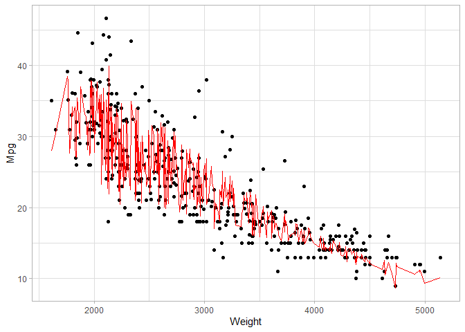

```r
fit <- lm(Mpg ~ Weight * Model_year + Acceleration * Weight, data=auto)

predicted_df <- data.frame(mpg_pred = predict(fit, auto), hp=auto$Weight)

# this is the predicted line of multiple linear regression
ggplot(data = auto, aes(y = Mpg, x = Weight)) +
  geom_point() +
  geom_line(color='red', data = predicted_df, aes(y=mpg_pred, x=hp)) +
  theme_light()
```

Se aprecia posible overfitting en el modelo, vamos a dejarlo por ahora e intentar solucionarlo con el modelo no lineal.

## Ajustes de regresión no lineal

Habíamos dicho que las gráficas nos mostraban una tendencia logarítmica, vamos a incluír la de Weight en nuestro modelo aditivo

```r
lm(Mpg ~ + Weight * Model_year + Acceleration * Weight + I(log(Weight)), data=auto) %>%
  summary()
```

```
Call:
lm(formula = Mpg ~ +Weight * Model_year + Acceleration * Weight +
    I(log(Weight)), data = auto)

Residuals:
    Min      1Q  Median      3Q     Max
-7.6734 -1.7933 -0.0576  1.3154 12.1716

Coefficients:
                      Estimate Std. Error t value Pr(>|t|)
(Intercept)          1.191e+02  4.120e+01   2.891  0.00406 **
Weight               2.842e-02  4.227e-03   6.723 6.44e-11 ***
Model_year           1.638e+00  1.728e-01   9.480  < 2e-16 ***
Acceleration         7.236e-01  2.435e-01   2.972  0.00315 **
I(log(Weight))      -3.028e+01  4.914e+00  -6.162 1.81e-09 ***
Weight:Model_year   -2.971e-04  6.186e-05  -4.803 2.24e-06 ***
Weight:Acceleration -1.775e-04  7.919e-05  -2.241  0.02559 *
---
Signif. codes:  0 '***' 0.001 '**' 0.01 '*' 0.05 '.' 0.1 ' ' 1

Residual standard error: 2.924 on 385 degrees of freedom
Multiple R-squared:  0.8618,    Adjusted R-squared:  0.8597
F-statistic: 400.2 on 6 and 385 DF,  p-value: < 2.2e-16
```

El estadístico F está bien y los p-valores también, aunque el de la interacción Weight-Acceleration es alto comparado con el resto (aún así sigue siendo aceptable).

Como el R<sup>2</sup> ha subido, por ver si mejora, vamos a quitar esta interacción.

```r
lm(Mpg ~ + Weight * Model_year + I(log(Weight)), data=auto) %>%
  summary()
```

```
Call:
lm(formula = Mpg ~ +Weight * Model_year + I(log(Weight)), data = auto)

Residuals:
    Min      1Q  Median      3Q     Max
-8.7501 -1.7470 -0.0725  1.3122 12.6776

Coefficients:
                    Estimate Std. Error t value Pr(>|t|)
(Intercept)        1.715e+02  3.810e+01   4.501 8.98e-06 ***
Weight             2.522e-02  4.119e-03   6.123 2.25e-09 ***
Model_year         1.572e+00  1.708e-01   9.202  < 2e-16 ***
I(log(Weight))    -3.540e+01  4.538e+00  -7.800 5.82e-14 ***
Weight:Model_year -2.701e-04  6.003e-05  -4.499 9.04e-06 ***
---
Signif. codes:  0 '***' 0.001 '**' 0.01 '*' 0.05 '.' 0.1 ' ' 1

Residual standard error: 2.972 on 387 degrees of freedom
Multiple R-squared:  0.8565,    Adjusted R-squared:  0.855
F-statistic: 577.3 on 4 and 387 DF,  p-value: < 2.2e-16
```

Hemos empeorado un 0.5%, bastante poco, y el modelo es más simple. La dejamos quitada.

Podemos mostrarlo en un gráfico:

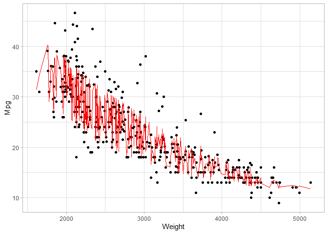

```r
fit <- lm(Mpg ~ + Weight * Model_year + I(log(Weight)), data=auto)

predicted_df <- data.frame(mpg_pred = predict(fit, auto), hp=auto$Weight)

# this is the predicted line of multiple linear regression
ggplot(data = auto, aes(y = Mpg, x = Weight)) +
  geom_point() +
  geom_line(color='red', data = predicted_df, aes(y=mpg_pred, x=hp)) +
  theme_light()
```

Esta gráfica nos indica que con casi toda probabilidad se está generando sobreajuste, se ve necesario simplificar el modelo.

Si quitamos la otra interacción:

```r
lm(Mpg ~ Weight + Model_year + I(log(Weight)), data=auto) %>% summary()
```

```
Call:
lm(formula = Mpg ~ Weight + Model_year + I(log(Weight)), data = auto)

Residuals:
    Min      1Q  Median      3Q     Max
-9.3384 -1.7476 -0.2122  1.5322 13.2812

Coefficients:
                 Estimate Std. Error t value Pr(>|t|)
(Intercept)    284.287315  29.392946   9.672  < 2e-16 ***
Weight           0.007772   0.001420   5.473 7.97e-08 ***
Model_year       0.828693   0.044506  18.620  < 2e-16 ***
I(log(Weight)) -43.590633   4.258803 -10.235  < 2e-16 ***
---
Signif. codes:  0 '***' 0.001 '**' 0.01 '*' 0.05 '.' 0.1 ' ' 1

Residual standard error: 3.045 on 388 degrees of freedom
Multiple R-squared:  0.849, Adjusted R-squared:  0.8478
F-statistic:   727 on 3 and 388 DF,  p-value: < 2.2e-16
```

No hemos perdido apenas R<sup>2</sup>, mostramos la gráfica:

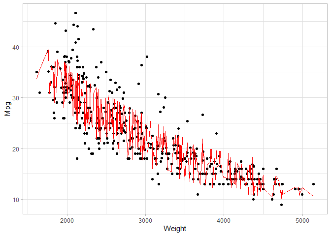

```r
fit <- lm(Mpg ~ Weight + Model_year+ I(log(Weight)), data=auto)

predicted_df <- data.frame(mpg_pred = predict(fit, auto), hp=auto$Weight)

# this is the predicted line of multiple linear regression
ggplot(data = auto, aes(y = Mpg, x = Weight)) +
  geom_point() +
  geom_line(color='red', data = predicted_df, aes(y=mpg_pred, x=hp)) +
  theme_light()
```

Seguimos con el mismo problema, probablemente se deba a una de las variables. Quitamos Model_year por tener poca correlación con la variable de salida:

```r
lm(Mpg ~ Weight + I(log(Weight)), data=auto) %>% summary()
```

```
Call:
lm(formula = Mpg ~ Weight + I(log(Weight)), data = auto)

Residuals:
     Min       1Q   Median       3Q      Max
-12.5329  -2.7031  -0.4016   1.7038  16.0835

Coefficients:
                 Estimate Std. Error t value Pr(>|t|)
(Intercept)    263.812407  40.366256   6.535 1.99e-10 ***
Weight           0.002582   0.001914   1.349    0.178
I(log(Weight)) -31.166013   5.780558  -5.392 1.21e-07 ***
---
Signif. codes:  0 '***' 0.001 '**' 0.01 '*' 0.05 '.' 0.1 ' ' 1

Residual standard error: 4.185 on 389 degrees of freedom
Multiple R-squared:  0.714, Adjusted R-squared:  0.7125
F-statistic: 485.6 on 2 and 389 DF,  p-value: < 2.2e-16
```

El p-valor de Weight nos indica que hay que quitarla, y al no estar incluída ninguna interacción, no es un término de jerarquía, por lo que podemos hacerlo. Se puede porque la variable sigue siendo independiente, solamente no está modelada de forma lineal, sino logarítmicamente.

```r
lm(Mpg ~ I(log(Weight)), data=auto) %>% summary()
```

```
Call:
lm(formula = Mpg ~ I(log(Weight)), data = auto)

Residuals:
     Min       1Q   Median       3Q      Max
-12.4315  -2.6752  -0.2888   1.9429  16.0136

Coefficients:
               Estimate Std. Error t value Pr(>|t|)
(Intercept)    209.9433     6.0002   34.99   <2e-16 ***
I(log(Weight)) -23.4317     0.7534  -31.10   <2e-16 ***
---
Signif. codes:  0 '***' 0.001 '**' 0.01 '*' 0.05 '.' 0.1 ' ' 1

Residual standard error: 4.189 on 390 degrees of freedom
Multiple R-squared:  0.7127,    Adjusted R-squared:  0.7119
F-statistic: 967.3 on 1 and 390 DF,  p-value: < 2.2e-16
```

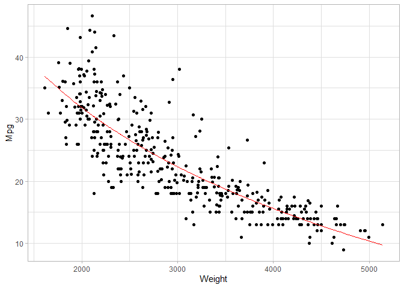

```r
fit <- lm(Mpg ~ I(log(Weight)), data=auto)

predicted_df <- data.frame(mpg_pred = predict(fit, auto), hp=auto$Weight)

# this is the predicted line of multiple linear regression
ggplot(data = auto, aes(y = Mpg, x = Weight)) +
  geom_point() +
  geom_line(color='red', data = predicted_df, aes(y=mpg_pred, x=hp)) +
  theme_light()
```

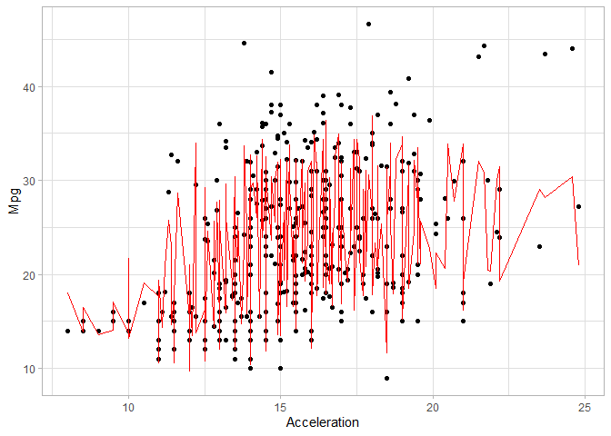

```r
predicted_df <- data.frame(mpg_pred = predict(fit, auto), hp=auto$Acceleration)

ggplot(data = auto, aes(y = Mpg, x = Acceleration)) +
  geom_point() +
  geom_line(color='red', data = predicted_df, aes(y=mpg_pred, x=hp)) +
  theme_light()
```

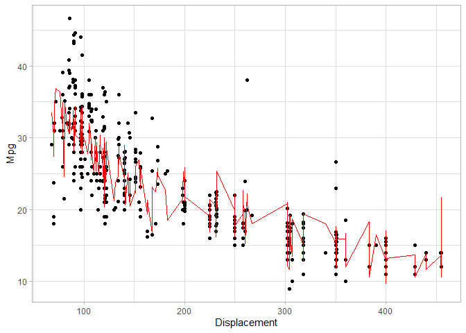

```r
predicted_df <- data.frame(mpg_pred = predict(fit, auto), hp=auto$Displacement)

ggplot(data = auto, aes(y = Mpg, x = Displacement)) +
  geom_point() +
  geom_line(color='red', data = predicted_df, aes(y=mpg_pred, x=hp)) +
  theme_light()
```

Vemos un empeoramiento significativo en la calidad de R<sup>2</sup> respecto al modelo multivariable, pero la forma del modelo no está tan ajustada a los datos y parece sensato mantenerlo así.

Aún así, no resulta lógico intentar predecir el Mpg de un coche únicamente en base al peso, alguna de las otras variables deberían ayudarnos en la predección. Por ejemplo, alguna característica del motor, como la cilindrada o los caballos de vapor.

Para resumir, mostramos el modelo con mejor R<sup>2</sup> tras hacer múltiples pruebas, e intentando evitar un overfitting:

```r
lm(Mpg ~ Acceleration + I(log(Weight)) + I(log(Displacement)), data=auto) %>%
  summary()
```

```
Call:
lm(formula = Mpg ~ Acceleration + I(log(Weight)) + I(log(Displacement)),
    data = auto)

Residuals:
     Min       1Q   Median       3Q      Max
-12.9074  -2.6174  -0.4104   1.9500  16.5596

Coefficients:
                      Estimate Std. Error t value Pr(>|t|)
(Intercept)          171.61778   12.14751  14.128  < 2e-16 ***
Acceleration           0.19717    0.08914   2.212   0.0276 *
I(log(Weight))       -16.94003    2.27727  -7.439 6.59e-13 ***
I(log(Displacement))  -3.19963    1.26881  -2.522   0.0121 *
---
Signif. codes:  0 '***' 0.001 '**' 0.01 '*' 0.05 '.' 0.1 ' ' 1

Residual standard error: 4.104 on 388 degrees of freedom
Multiple R-squared:  0.7256,    Adjusted R-squared:  0.7235
F-statistic: 342.1 on 3 and 388 DF,  p-value: < 2.2e-16
```

Los p-valores no son muy fuertes, pero siguen siendo aceptables, y gráficamente el modelo se ve un poco mejor:

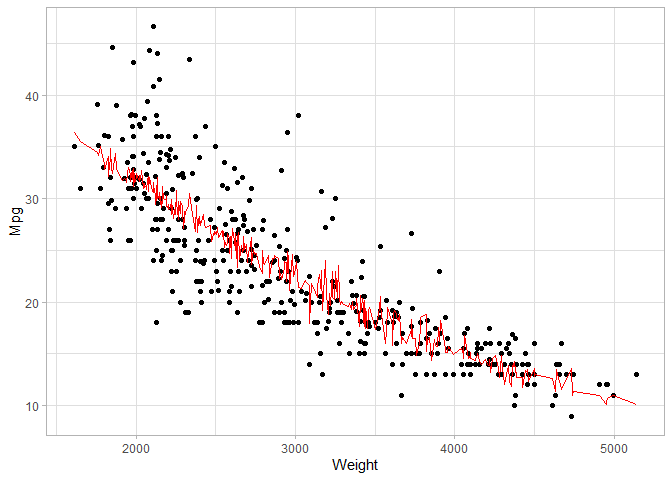

```r
fit <- lm(Mpg ~ Acceleration + I(log(Weight)) + I(log(Displacement)), data=auto)

predicted_df <- data.frame(mpg_pred = predict(fit, auto), hp=auto$Weight)

# this is the predicted line of multiple linear regression
ggplot(data = auto, aes(y = Mpg, x = Weight)) +
  geom_point() +
  geom_line(color='red', data = predicted_df, aes(y=mpg_pred, x=hp)) +
  theme_light()
```

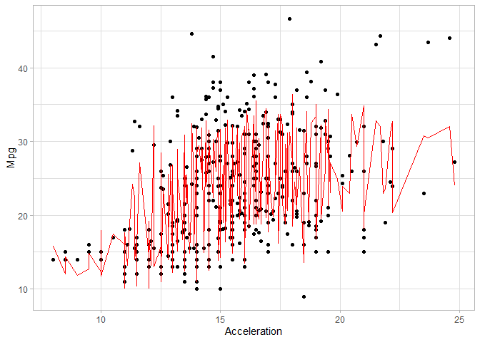

```r
predicted_df <- data.frame(mpg_pred = predict(fit, auto), hp=auto$Acceleration)

ggplot(data = auto, aes(y = Mpg, x = Acceleration)) +
  geom_point() +
  geom_line(color='red', data = predicted_df, aes(y=mpg_pred, x=hp)) +
  theme_light()
```

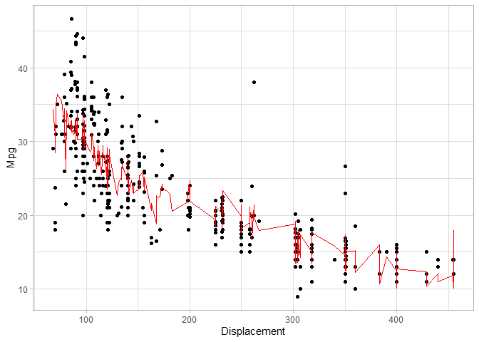

```r
predicted_df <- data.frame(mpg_pred = predict(fit, auto), hp=auto$Displacement)

ggplot(data = auto, aes(y = Mpg, x = Displacement)) +
  geom_point() +
  geom_line(color='red', data = predicted_df, aes(y=mpg_pred, x=hp)) +
  theme_light()
```

Pensando en el problema, y tras el análisis hecho en el apartado de EDA, creemos que usar Model_year para predecir Mpg no parece buena idea. La gráfica de la variable nos muestran mucha dispersión en los datos y, aunque sí se ve un cierta tendencia lineal, no parece suficiente para usarla. Claramente nos ajusta mejor los datos pero parece que nos estamos pegando a ellos.

De cara a comprobar este razonamiento en el cross-validation, vamos a guardar dos modelos: - Modelo con mejor R<sup>2</sup> Mpg ~ Weight + Model_year + I(log(Weight)

- Modelo intentando evitar el overfitting Mpg ~ Acceleration + I(log(Weight)) + I(log(Displacement))

## Ajustes con KNN

Sabemos que la función por defecto usa la distancia de Minkowski y escala los datos a igual rango. También usa un k de 7, y sería recomendable probar con varios.

Vamos a probar con diferentes modelos, primero el multivariable con todas

```r
fitknn <- kknn(Mpg~., auto, auto)

yprime <- fitknn$fitted.values
sqrt(sum((auto$Mpg - yprime)^2)/length(yprime)) #RMSE
```

```
[1] 1.880835
```

Y probando con varios obtenemos el menor error con este

```r
fitknn <- kknn(Mpg~.-Acceleration, auto, auto)

yprime <- fitknn$fitted.values
sqrt(sum((auto$Mpg - yprime)^2)/length(yprime)) #RMSE
```

```
[1] 1.856269
```

Que visualmente nos quedaría

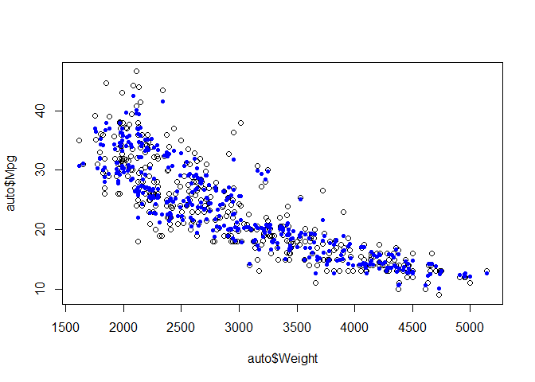

```r
plot(auto$Mpg~auto$Weight)
points(auto$Weight,fitknn$fitted.values,col="blue",pch=20)
```

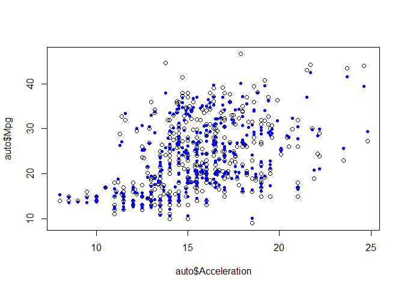

```r
plot(auto$Mpg~auto$Acceleration)
points(auto$Acceleration,fitknn$fitted.values,col="blue",pch=20)
```

Si probamos el modelo no lineal obtenido en los pasos anteriores (con mejor R<sup>2</sup>)

```r
fitknn <- kknn(Mpg ~ Weight + Model_year + I(log(Weight)), auto, auto)

yprime <- fitknn$fitted.values
sqrt(sum((auto$Mpg - yprime)^2)/length(yprime)) #RMSE
```

```
[1] 2.104086
```

Nos da peor error.

Y si probamos el modelo no lineal en el que intemos resolver el overfitting

```r
fitknn2 <- kknn(Mpg ~ Acceleration + I(log(Weight)) + I(log(Displacement)), auto, auto)

yprime <- fitknn2$fitted.values
sqrt(sum((auto$Mpg - yprime)^2)/length(yprime)) #RMSE
```

```
[1] 2.938051
```

Obtenemos aún mayor empeoramiento. Gráficamente:

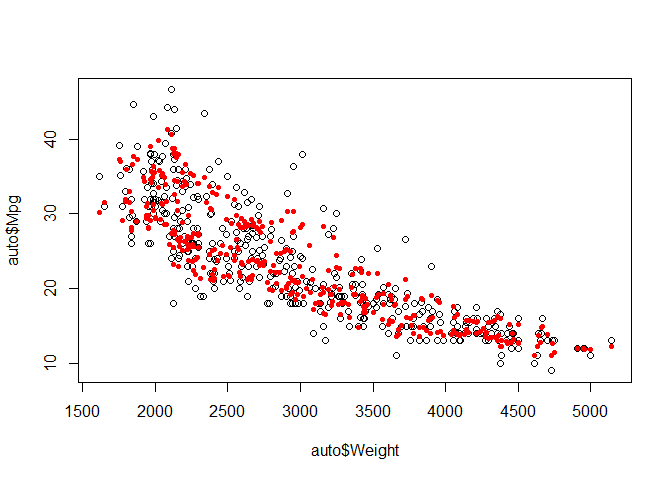

```r
plot(auto$Mpg~auto$Weight)
points(auto$Weight,fitknn$fitted.values,col="red",pch=20)
```

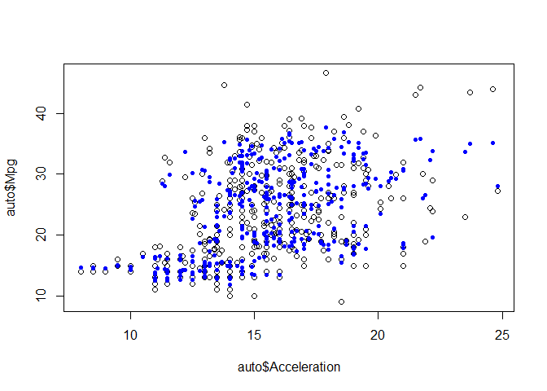

```r
plot(auto$Mpg~auto$Acceleration)
points(auto$Acceleration,fitknn2$fitted.values,col="blue",pch=20)
```

El método para evitar el overfitting que usamos en el apartado anterior probablemente no funcione con KNN por seguir una metodología totalmente diferente. El ajuste de KNN para regresión no tiene nada que ver con los modelos LM. Podemos aún así guardarlo para comprobarlo.

Tendríamos por tanto los siguientes modelos para KNN: Mpg ~ . - Acceleration Mpg ~ Acceleration + I(log(Weight)) + I(log(Displacement))

Comparandolos gráficamente, vemos que son similares

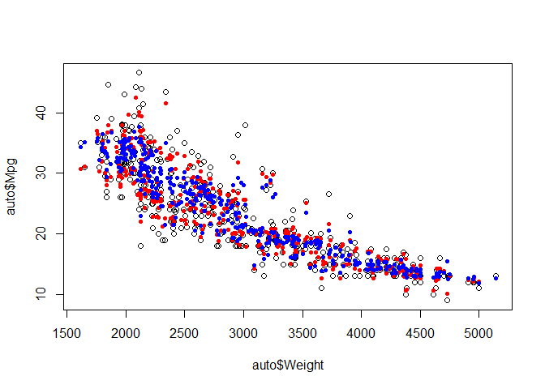

```r
fitknn <- kknn(Mpg ~ . - Acceleration, auto, auto)
fitknn2 <- kknn(Mpg ~ Acceleration + I(log(Weight)) + I(log(Displacement)), auto, auto)

plot(auto$Mpg~auto$Weight)
points(auto$Weight,fitknn$fitted.values,col="red",pch=20)
points(auto$Weight,fitknn2$fitted.values,col="blue",pch=20)
```

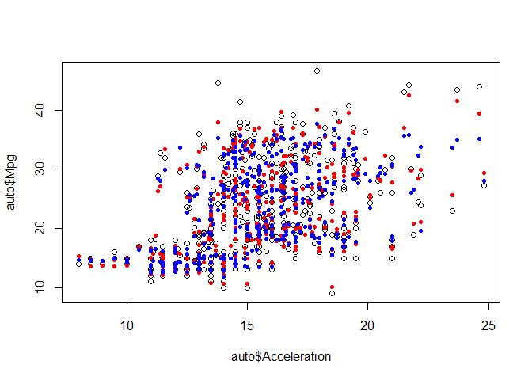

```r
plot(auto$Mpg~auto$Acceleration)
points(auto$Acceleration,fitknn$fitted.values,col="red",pch=20)
points(auto$Acceleration,fitknn2$fitted.values,col="blue",pch=20)
```

Aunque el que intenta evitar el overfitting (en color azul en la gráfica), tiene menor dispersión.

## Comparativa de los ajustes anteriores con cross-validation

Recordamos los modelos obtenidos: LM: Mpg ~ Weight + Model_year + I(log(Weight) Mpg ~ Acceleration + I(log(Weight)) + I(log(Displacement))

KNN: Mpg ~ . - Acceleration Mpg ~ Acceleration + I(log(Weight)) + I(log(Displacement))

c(“Displacement”, “Horse_power”, “Weight”, “Acceleration”, “Model_year”, “Mpg”) X1 X2 X3 X4 X5 Y

LM: Y ~ X3 + X5 + I(log(X3)) Y ~ X4 + I(log(X3)) + I(log(X1))

KNN: Y ~ . - X4 Y ~ X4 + I(log(X3)) + I(log(X1))

```r
nombre <- "Data/autoMPG6/autoMPG6"
```

Modelo de regresión con mejor R<sup>2</sup>

```r
#------------- 5-fold cross-validation LM todas las variables
run_lm_fold <- function(i, x, tt = "test") {
    file <- paste(x, "-5-", i, "tra.dat", sep="")
    x_tra <- read.csv(file, comment.char="@", header=FALSE)
    file <- paste(x, "-5-", i, "tst.dat", sep="")
    x_tst <- read.csv(file, comment.char="@", header=FALSE)
    In <- length(names(x_tra)) - 1

    names(x_tra)[1:In] <- paste ("X", 1:In, sep="")
    names(x_tra)[In+1] <- "Y"
    names(x_tst)[1:In] <- paste ("X", 1:In, sep="")
    names(x_tst)[In+1] <- "Y"

    if (tt == "train") {
        test <- x_tra
    }
    else {
        test <- x_tst
    }

    fitMulti=lm(Y ~ X3 + X5 + I(log(X3)),x_tra)  # Poner la fórmula aquí

    yprime=predict(fitMulti,test)
    sum(abs(test$Y-yprime)^2)/length(yprime) ## RMSE
}

lmMSEtrain1 <- mean(sapply(1:5,run_lm_fold,nombre,"train"))
lmMSEtest1 <- mean(sapply(1:5,run_lm_fold,nombre,"test"))
```

Modelo de regresión evitando overfitting

```r
#------------- 5-fold cross-validation LM todas las variables
run_lm_fold <- function(i, x, tt = "test") {
    file <- paste(x, "-5-", i, "tra.dat", sep="")
    x_tra <- read.csv(file, comment.char="@", header=FALSE)
    file <- paste(x, "-5-", i, "tst.dat", sep="")
    x_tst <- read.csv(file, comment.char="@", header=FALSE)
    In <- length(names(x_tra)) - 1

    names(x_tra)[1:In] <- paste ("X", 1:In, sep="")
    names(x_tra)[In+1] <- "Y"
    names(x_tst)[1:In] <- paste ("X", 1:In, sep="")
    names(x_tst)[In+1] <- "Y"

    if (tt == "train") {
        test <- x_tra
    }
    else {
        test <- x_tst
    }

    fitMulti=lm(Y ~ X4 + I(log(X3)) + I(log(X1)),x_tra)  # Poner la fórmula aquí

    yprime=predict(fitMulti,test)
    sum(abs(test$Y-yprime)^2)/length(yprime) ## RMSE
}

lmMSEtrain2 <- mean(sapply(1:5,run_lm_fold,nombre,"train"))
lmMSEtest2 <- mean(sapply(1:5,run_lm_fold,nombre,"test"))
```

Modelo KNN con menor RSME

```r
#------------- 5-fold cross-validation KNN todas las variables
run_knn_fold <- function(i, x, tt = "test") {
    file <- paste(x, "-5-", i, "tra.dat", sep="")
    x_tra <- read.csv(file, comment.char="@", header=FALSE)
    file <- paste(x, "-5-", i, "tst.dat", sep="")
    x_tst <- read.csv(file, comment.char="@", header=FALSE)
    In <- length(names(x_tra)) - 1

    names(x_tra)[1:In] <- paste ("X", 1:In, sep="")
    names(x_tra)[In+1] <- "Y"
    names(x_tst)[1:In] <- paste ("X", 1:In, sep="")
    names(x_tst)[In+1] <- "Y"

    if (tt == "train") {
        test <- x_tra
    }
    else {
        test <- x_tst
    }

    fitMulti=kknn(Y ~ . - X4,x_tra,test)  # Poner la fórmula aquí

    yprime=fitMulti$fitted.values
    sum(abs(test$Y-yprime)^2)/length(yprime) ##RMSE
}

knnMSEtrain1 <- mean(sapply(1:5,run_knn_fold,nombre,"train"))
knnMSEtest1 <- mean(sapply(1:5,run_knn_fold,nombre,"test"))
```

Modelo KNN evitando overfitting

```r
#------------- 5-fold cross-validation KNN todas las variables
run_knn_fold <- function(i, x, tt = "test") {
    file <- paste(x, "-5-", i, "tra.dat", sep="")
    x_tra <- read.csv(file, comment.char="@", header=FALSE)
    file <- paste(x, "-5-", i, "tst.dat", sep="")
    x_tst <- read.csv(file, comment.char="@", header=FALSE)
    In <- length(names(x_tra)) - 1

    names(x_tra)[1:In] <- paste ("X", 1:In, sep="")
    names(x_tra)[In+1] <- "Y"
    names(x_tst)[1:In] <- paste ("X", 1:In, sep="")
    names(x_tst)[In+1] <- "Y"

    if (tt == "train") {
        test <- x_tra
    }
    else {
        test <- x_tst
    }

    fitMulti=kknn(Y ~ X4 + I(log(X3)) + I(log(X1)),x_tra,test)  # Poner la fórmula aquí

    yprime=fitMulti$fitted.values
    sum(abs(test$Y-yprime)^2)/length(yprime) ##RMSE
}

knnMSEtrain2 <- mean(sapply(1:5,run_knn_fold,nombre,"train"))
knnMSEtest2 <- mean(sapply(1:5,run_knn_fold,nombre,"test"))
```

Resultados obtenidos

```r
cat("Regresión 1: ")
lmMSEtest1
cat("Regresión 2: ")
lmMSEtest2
cat("KNN 1: ")
knnMSEtest1
cat("KNN 2: ")
knnMSEtest2
```

```
Regresión 1: [1] 9.333066
Regresión 2: [1] 17.10519
KNN 1: [1] 7.291517
KNN 2: [1] 18.43846
```

Con el proceso de cross-validation dividimos el dataset en N subconjuntos (folds) y repetimos el entrenamiento N veces. Cada entrenamiento se aplica reservando uno de los subconjuntos como test y entrenando con el resto. Al final, el error obtenido para el modelo es la media de los errores en cada fold. La elección del número de folds es importante y si el problema lo permite (en términos de gasto computacional), se debería probar con varios. En este caso hemos utilizado 5 folds.

Con esto conseguimos no desperdiciar el conocimiento del conjunto de test y no guiarnos por una única evaluación del modelo.

Como resultados, nos muestra que los modelos con los que obtuvimos mejores resultados de R2 y RSME en sus apartados han acabado con mejor RSME tras el cross-validation. También apreciamos que con KNN conseguimos ligeramente mejores resultados.

Por completitud, mostramos también los resultados en training

```r
cat("Regresión 1: ")
lmMSEtrain1
cat("Regresión 2: ")
lmMSEtrain2
cat("KNN 1: ")
knnMSEtrain1
cat("KNN 2: ")
knnMSEtrain2
```

```
Regresión 1: [1] 9.159891
Regresión 2: [1] 16.62285
KNN 1: [1] 3.659828
KNN 2: [1] 8.642349
```

Que nos muestran que ninguno de los modelos LM estaban haciendo overfitting, pero en cambio en KNN si existe una diferencia significativa entre training y test.

## Comparativa de tests

Para comparar los algoritmos vamos a aplicar test estadísticos en base a los resultados obtenidos en múltiples datasets. Para asegurar la igualdad de condiciones los algoritmos hacen uso de parámetros genéricos y utilizan las mismas particiones de cross-validation.

Estas son las tablas de resultados que tenemos:

```r
# Leemos la tabla con los errores medios de test
resultados <- read.csv("Data/regr_test_alumnos.csv")
tablatst <- cbind(resultados[,2:dim(resultados)[2]])
colnames(tablatst) <- names(resultados)[2:dim(resultados)[2]]
rownames(tablatst) <- resultados[,1]

# Leemos la tabla con los errores medios de entrenamiento
resultados <- read.csv("Data/regr_train_alumnos.csv")
tablatra <- cbind(resultados[,2:dim(resultados)[2]])
colnames(tablatra) <- names(resultados)[2:dim(resultados)[2]]
rownames(tablatra) <- resultados[,1]

# TABLA NORMALIZADA - lm (other) vs knn (ref) para WILCOXON
# + 0.1 porque wilcox R falla para valores == 0 en la tabla

difs <- (tablatst[,1] - tablatst[,2]) / tablatst[,1]
wilc_1_2 <- cbind(ifelse (difs<0, abs(difs)+0.1, 0+0.1), ifelse (difs>0,    abs(difs)+0.1, 0+0.1))
colnames(wilc_1_2) <- c(colnames(tablatst)[1], colnames(tablatst)[2])
head(wilc_1_2 %>% as.data.frame())
```

|  | out_test_lm | out_test_kknn |
| --- | --- | --- |
| 1 | 0.1909091 | 0.1000000 |
| 2 | 0.1000000 | 1.0294118 |
| 3 | 0.1000000 | 0.4339071 |
| 4 | 0.1000000 | 0.3885965 |
| 5 | 0.1548506 | 0.1000000 |
| 6 | 0.1000000 | 0.3061057 |

Aplicamos el test de Wilconxon a LM y KNN

```r
# Aplicación del test de WILCOXON
LMvsKNNtst <- wilcox.test(wilc_1_2[,1], wilc_1_2[,2], alternative = "two.sided", paired=TRUE)
Rmas <- LMvsKNNtst$statistic

pvalue <- LMvsKNNtst$p.value

LMvsKNNtst <- wilcox.test(wilc_1_2[,2], wilc_1_2[,1], alternative = "two.sided", paired=TRUE)
Rmenos <- LMvsKNNtst$statistic

Rmas
Rmenos
cat("p-value: ")
pvalue
```

```
 V
78
 V
93
p-value: [1] 0.7660294
```

Ahora aplicamos en test de Friedman a los dos algoritmos anterios junto al algoritmo M5:

```r
# Aplicación del test de Friedman
test_friedman <- friedman.test(as.matrix(tablatst))
test_friedman
```

```
    Friedman rank sum test

data:  as.matrix(tablatst)
Friedman chi-squared = 8.4444, df = 2, p-value = 0.01467
```

El p-value es <0.05 por lo que podemos concluir que al menos hay un par de algoritmos de calidad diferente.

Vemos cuáles de ellos lo son haciendo el test post-hoc de HOLM

```r
# Aplicación del test post-hoc de HOLM
tam <- dim(tablatst)
groups <- rep(1:tam[2], each=tam[1])
pairwise.wilcox.test(as.matrix(tablatst), groups, p.adjust = "holm", paired = TRUE)
```

```
    Pairwise comparisons using Wilcoxon signed rank exact test

data:  as.matrix(tablatst) and groups

  1     2
2 0.580 -
3 0.081 0.108

P value adjustment method: holm
```

De KNN y LM no podemos afirmar nada puesto que el p-valor es extremadamente grande.